# 3D simulated case study: Diagnosis of the HSGP approximation

Gabriel Riutort-Mayol

2022-05-16.

This notebook implements the HSGP model fit and diagnosis on the 3D dataset in case study 5.3 ‘*Simulated data for 2D and 3D functions*’ in [Riutort-Mayol, G., Bürkner, P. C., Andersen, M. R., Solin, A., & Vehtari, A. (2020; updated in 2022). Practical Hilbert space approximate Bayesian Gaussian processes for probabilistic programming. arXiv preprint arXiv:2004.11408.](https://arxiv.org/pdf/2004.11408.pdf)

# 1 Load packages

```r
library(rstan)
library(cmdstanr)
options(mc.cores = parallel::detectCores())
rstan_options(auto_write = FALSE)
library(posterior)
library(bayesplot)
library(RColorBrewer)
library(ggplot2)
```

# 2 Synthetic dataset

A synthetic dataset $\boldsymbol{y}$ with a true data generating function $f(\boldsymbol{x})$, with $\boldsymbol{x}_i \in {\rm I\!R}^3$, where $f(\boldsymbol{x})$ is a Gaussian process (GP) with a squared exponential kernel. Gaussian errors $\boldsymbol{\epsilon}$ are added to $f(\boldsymbol{x})$ to form the final synthetic noisy dataset $\boldsymbol{y}$.

$$\begin{align*}
\begin{split}
\boldsymbol{y} &= \boldsymbol{f} + \boldsymbol{\epsilon} \\
\boldsymbol{\epsilon} &\sim \text{Normal}(\boldsymbol{0}, \sigma^2 \boldsymbol{I}) \\
f(\boldsymbol{x}) &\sim \text{GP}(0, k(\boldsymbol{x}, \boldsymbol{x}', \theta)),
\end{split}
\end{align*}$$

where $k(\boldsymbol{x}, \boldsymbol{x}', \theta)$ is a squared exponential kernel as a function of input values $\boldsymbol{x}$ and parameters $\theta=(\alpha,\boldsymbol{\ell})$, where $\alpha$ is the marginal variance of the GP function and $\boldsymbol{\ell}=(\ell_1,\ell_2,\ell_3)$ the lengthscale of the kernel for dimensions 1, 2 and 3, respectively.

## 2.1 Draw the true data generative function $f(x)$ from a GP

### 2.1.1 Input predictive space

Matrix of 3D-predictive input points `x_pred`

```r
x_pred <- expand.grid(x1= seq(-1,1,by=0.2), x2= seq(-1,1,by=0.2), x3= seq(-1,1,by=0.2))
str(x_pred)
```

```
'data.frame':   1331 obs. of  3 variables:
 $ x1: num  -1 -0.8 -0.6 -0.4 -0.2 0 0.2 0.4 0.6 0.8 ...
 $ x2: num  -1 -1 -1 -1 -1 -1 -1 -1 -1 -1 ...
 $ x3: num  -1 -1 -1 -1 -1 -1 -1 -1 -1 -1 ...
 - attr(*, "out.attrs")=List of 2
  ..$ dim     : Named int [1:3] 11 11 11
  .. ..- attr(*, "names")= chr [1:3] "x1" "x2" "x3"
  ..$ dimnames:List of 3
  .. ..$ x1: chr [1:11] "x1=-1.0" "x1=-0.8" "x1=-0.6" "x1=-0.4" ...
  .. ..$ x2: chr [1:11] "x2=-1.0" "x2=-0.8" "x2=-0.6" "x2=-0.4" ...
  .. ..$ x3: chr [1:11] "x3=-1.0" "x3=-0.8" "x3=-0.6" "x3=-0.4" ...
```

Length of `x_pred` (`N_pred`)

```r
N_pred <- dim(x_pred)[1]
N_pred
```

```
[1] 1331
```

Number of dimensions `D`

```r
D <- 3
D
```

```
[1] 3
```

Half range `S` of every input dimension

```r
S1 <- abs((max(x_pred$x1) - min(x_pred$x1))/2)
S1
```

```
[1] 1
```

```r
S2 <- abs((max(x_pred$x2) - min(x_pred$x2))/2)
S2
```

```
[1] 1
```

```r
S3 <- abs((max(x_pred$x3) - min(x_pred$x3))/2)
S3
```

```
[1] 1
```

### 2.1.2 Draw $f(x)$ using Stan

Marginal variance `gpscale` ($\alpha$) and multivariate lengthscale `lscale` ($\boldsymbol{\ell}$)

```r
gpscale <- 1
lscale <- vector()
lscale[1] <- 0.1
lscale[2] <- 0.3
lscale[3] <- 0.4
```

Random variable `eta` to simulate from the GP

```r
seed <- 88646
set.seed(seed)
eta <- rnorm(N_pred, 0, 1)
```

Data to be passed to Stan

```r
standata <- list(D= D,
                 N_pred= N_pred,
                 x_pred= x_pred,
                 gpscale= gpscale,
                 lscale= lscale,
                 eta= eta)
```

Model sampling

```r
simuGP_mod <- cmdstanr::cmdstan_model(stan_file = "stancode_SIMU_3D.stan")
fit_SIMU <- simuGP_mod$sample(data= standata,
                                iter_warmup=1,
                                iter_sampling=1,
                                chains=1, thin=1, init=0.5,
                                fixed_param=TRUE)
fit_SIMU <- read_stan_csv(fit_SIMU$output_files())
```

## 2.2 Adding noise to $f(x)$

```r
f_true <- extract(fit_SIMU, pars="f_true", permuted = TRUE, inc_warmup = FALSE, include = TRUE)$f_true[1,]
set.seed(1234)
y_pred <- f_true + rnorm(N_pred, 0, 0.2)
```

## 2.3 Noisy data set

```r
nobs <- 300
set.seed(4567)
vv_sample <- sample(1:N_pred, nobs)
N_sample <- length(vv_sample)
```

# 3 GP model fitting

## 3.1 Data

Data to Stan

```r
standata_GP <- list(D= D,
                    N_sample= N_sample,
                    vv_sample= vv_sample,
                    N_pred= N_pred,
                    x_pred= x_pred,
                    y_pred= y_pred)
str(standata_GP)
```

```
List of 6
 $ D        : num 3
 $ N_sample : int 300
 $ vv_sample: int [1:300] 798 1044 387 786 144 392 522 205 980 71 ...
 $ N_pred   : int 1331
 $ x_pred   :'data.frame':  1331 obs. of  3 variables:
  ..$ x1: num [1:1331] -1 -0.8 -0.6 -0.4 -0.2 0 0.2 0.4 0.6 0.8 ...
  ..$ x2: num [1:1331] -1 -1 -1 -1 -1 -1 -1 -1 -1 -1 ...
  ..$ x3: num [1:1331] -1 -1 -1 -1 -1 -1 -1 -1 -1 -1 ...
  ..- attr(*, "out.attrs")=List of 2
  .. ..$ dim     : Named int [1:3] 11 11 11
  .. .. ..- attr(*, "names")= chr [1:3] "x1" "x2" "x3"
  .. ..$ dimnames:List of 3
  .. .. ..$ x1: chr [1:11] "x1=-1.0" "x1=-0.8" "x1=-0.6" "x1=-0.4" ...
  .. .. ..$ x2: chr [1:11] "x2=-1.0" "x2=-0.8" "x2=-0.6" "x2=-0.4" ...
  .. .. ..$ x3: chr [1:11] "x3=-1.0" "x3=-0.8" "x3=-0.6" "x3=-0.4" ...
 $ y_pred   : num [1:1331] 0.0105 0.3424 0.537 -0.4404 -1.4484 ...
```

## 3.2 Model fitting

Model fitting

```r
GP_mod <- cmdstanr::cmdstan_model(stan_file = "stancode_GP_marginalized_3D.stan")
fit_GP <- GP_mod$sample(data= standata_GP,
                          iter_warmup=50,
                          iter_sampling=50,
                          chains=4, thin=1, init=2,
                          save_warmup=TRUE)
fit_GP <- read_stan_csv(fit_GP$output_files())
```

Summaries and simulation chains for the variables after warmup

```r
param = c("lscale","gpscale","sigma")
print(summary(fit_GP, pars = param, probs = c(0.025, 0.5, 0.975))$summary)
```

```
               mean     se_mean         sd       2.5%       50%     97.5%
lscale[1] 0.1134330 0.001117415 0.01215498 0.08536432 0.1156100 0.1323140
lscale[2] 0.3191217 0.001628892 0.02192847 0.27898085 0.3205695 0.3592232
lscale[3] 0.4389002 0.002098915 0.03284735 0.38472005 0.4375740 0.5078690
gpscale   1.1199874 0.004998118 0.06960650 0.99323272 1.1167000 1.2596850
sigma     0.2136205 0.004127805 0.03119900 0.16475915 0.2118310 0.2768175
              n_eff      Rhat
lscale[1] 118.32570 1.0670901
lscale[2] 181.23082 0.9938647
lscale[3] 244.91236 1.0077387
gpscale   193.94859 1.0005737
sigma      57.12719 1.0240733
```

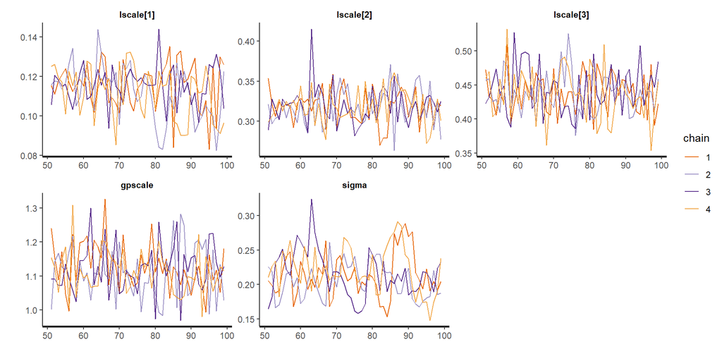

```r
traceplot(fit_GP, pars = param, include = TRUE, unconstrain = FALSE, inc_warmup = FALSE, window = NULL, nrow = NULL, ncol = NULL)
```

## 3.3 Posterior predictive distribution

```r
f_gp <- summary(fit_GP, pars = c("f_pred"), probs = c(0.025, 0.5, 0.975), digits_summary = 4)$summary[,c(1,4,6)]
```

# 4 Functional relationships among $m$, $\ell$ and $c$ parameters in the HSGP approach

Relationship among the number of basis functions $m$, the lengthscale $\ell$ and the boundary factor $c$ for a **squared exponential kernel** in the HSGP approach:

$$\begin{align*}
m= 1.75 \frac{c}{\frac{\ell}{S}} \;\; \Leftrightarrow \;\; \frac{\ell}{S}= 1.75 \, \frac{c}{m} \tag{4.1}
\end{align*}$$

```r
m_QE <- function(c,l,S) ceiling(1.75 * c / (l/S))
l_QE <- function(c,m,S) round(S * 1.75 * c / m, 3)
```

as a function of $\ell$ and $S$, where $S$ is the half range of the input domain

```r
c_vs_l_QE <- function(l,S){
    c =  3.2*l/S
    if(c < 1.2)
      c = 1.2
  c
}
```

# 5 Lengthscale diagnostic

The HSGP lengthscale diagnostic is defined as:

$$\begin{align*}
\hat{\ell} + 0.01 \geq \ell \tag{5.1}
\end{align*}$$

```r
diagnostic <- function(l,l_hat) l_hat + 0.01 >= l
```

# 6 HSGP fit and diagnosis

Initializing programming objects.

```r
standata <- list()
fit<- list()
diagnosis <- list()

l1 <- vector()  # lengthscale for dimension 1
l2 <- vector()  # lengthscale for dimension 2
l3 <- vector()  # lengthscale for dimension 3
c1 <- vector()  # boundary factor for dimension 1
c2 <- vector()  # boundary factor for dimension 2
c3 <- vector()  # boundary factor for dimension 3
m1 <- vector()  # number of basis functions for dimension 1
m2 <- vector()  # number of basis functions for dimension 2
m3 <- vector()  # number of basis functions for dimension 3
l_hat1 <- vector()  # HSGP lengthscale estimate for dimension 1
l_hat2 <- vector()  # HSGP lengthscale estimate for dimension 2
l_hat3 <- vector()  # HSGP lengthscale estimate for dimension 3
check1 <- vector()  # Diagnostic for dimension 1
check2 <- vector()  # Diagnostic for dimension 2
check3 <- vector()  # Diagnostic for dimension 3
rmse_gp <- vector()  # root mean square error of GP model
rmse <- vector()  # root mean square error of HSGP model
eR <- vector()  # coefficient of determination of HSGP model
elpd <- vector()  # expected log predictive density of HSGP model
```

## 6.1 Iteration 1

```r
i <- 1
print(paste("Iteration i =", i), quote = FALSE)
```

```
[1] Iteration i = 1
```

### 6.1.1 Setting $m$, $\ell$ and $c$

If iteration $i=1$:

1. Making a first guess for lengthscale $\ell_i$
2. The boundary factor $c_i$ has to fulfill equation (4.2)
3. The number of basis functions $m_i$ has to fulfill equation (4.1)

```r
if(i==1){
  l1[i] <- 0.5
  c1[i] <- c_vs_l_QE(l=l1[i], S1)
  m1[i] <- m_QE(c=c1[i], l=l1[i], S=S1)

  l2[i] <- 0.5
  c2[i] <- c_vs_l_QE(l=l2[i], S2)
  m2[i] <- m_QE(c=c2[i], l=l2[i], S=S2)

  l3[i] <- 1
  c3[i] <- c_vs_l_QE(l=l3[i], S3)
  m3[i] <- m_QE(c=c3[i], l=l3[i], S=S3)
}
```

### 6.1.2 Matrix of $D$-tuples

Matrix of $D$-tuples as in equation (10) in the [paper](https://arxiv.org/pdf/2004.11408.pdf)

```r
indices <- matrix(NA, m1[i]*m2[i]*m3[i], D)
mm=0;
for (r in 1:m1[i]){
    for (s in 1:m2[i]){
        for (t in 1:m3[i]){
            mm = mm+1
            indices[mm,] = c(r, s, t)
        }
    }
}
```

### 6.1.3 Data to be passed to Stan

```r
standata[[i]] <- list(D= D,
                      M= c(m1[i],m2[i],m3[i]),
                      M_nD= m1[i]*m2[i]*m3[i],
                      indices= indices,
                      L= c(c1[i], c2[i], c3[i]) * c(S1, S2, S3),
                      x_pred= x_pred,
                      y_pred= y_pred,
                      N_sample= N_sample,
                      N_pred= N_pred,
                      vv_sample= vv_sample
)
str(standata[[i]])
```

```
List of 10
 $ D        : num 3
 $ M        : num [1:3] 6 6 6
 $ M_nD     : num 216
 $ indices  : int [1:216, 1:3] 1 1 1 1 1 1 1 1 1 1 ...
 $ L        : num [1:3] 1.6 1.6 3.2
 $ x_pred   :'data.frame':  1331 obs. of  3 variables:
  ..$ x1: num [1:1331] -1 -0.8 -0.6 -0.4 -0.2 0 0.2 0.4 0.6 0.8 ...
  ..$ x2: num [1:1331] -1 -1 -1 -1 -1 -1 -1 -1 -1 -1 ...
  ..$ x3: num [1:1331] -1 -1 -1 -1 -1 -1 -1 -1 -1 -1 ...
  ..- attr(*, "out.attrs")=List of 2
  .. ..$ dim     : Named int [1:3] 11 11 11
  .. .. ..- attr(*, "names")= chr [1:3] "x1" "x2" "x3"
  .. ..$ dimnames:List of 3
  .. .. ..$ x1: chr [1:11] "x1=-1.0" "x1=-0.8" "x1=-0.6" "x1=-0.4" ...
  .. .. ..$ x2: chr [1:11] "x2=-1.0" "x2=-0.8" "x2=-0.6" "x2=-0.4" ...
  .. .. ..$ x3: chr [1:11] "x3=-1.0" "x3=-0.8" "x3=-0.6" "x3=-0.4" ...
 $ y_pred   : num [1:1331] 0.0105 0.3424 0.537 -0.4404 -1.4484 ...
 $ N_sample : int 300
 $ N_pred   : int 1331
 $ vv_sample: int [1:300] 798 1044 387 786 144 392 522 205 980 71 ...
```

### 6.1.4 Model fitting

Model fitting

```r
hsgp_mod <- cmdstanr::cmdstan_model(stan_file = "stancode_HSGP_3D.stan")
fit[[i]] <- hsgp_mod$sample(data= standata[[i]],
                                iter_warmup=100,
                                iter_sampling=150,
                                chains=4, thin=3, init=0.5,
                                # adapt_delta=0.99,
                                save_warmup=TRUE)
fit[[i]] <- rstan::read_stan_csv(fit[[i]]$output_files())
```

Summaries and simulation chains of variable estimates

```r
param = c("lscale","gpscale","noise")
summary(fit[[i]], pars = param, probs = c(0.025, 0.5, 0.975))$summary
```

```
               mean     se_mean         sd       2.5%       50%     97.5%
lscale[1] 0.1386528 0.002798347 0.04246453 0.06139556 0.1358015 0.2312433
lscale[2] 0.2553978 0.004927873 0.07221749 0.10697603 0.2591280 0.3816168
lscale[3] 0.2426228 0.009200419 0.12279573 0.08280365 0.2192430 0.5387436
gpscale   2.0051773 0.035650147 0.52534309 1.23810375 1.9308000 3.1917723
noise     0.7254873 0.002939711 0.03669954 0.66304172 0.7221860 0.8094907
             n_eff      Rhat
lscale[1] 230.2765 0.9942920
lscale[2] 214.7661 1.0094077
lscale[3] 178.1359 1.0016087
gpscale   217.1518 0.9886618
noise     155.8518 0.9894604
```

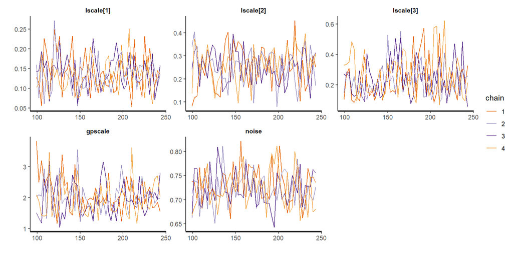

```r
traceplot(fit[[i]], pars = param, include = TRUE, unconstrain = FALSE, inc_warmup = FALSE, window = NULL, nrow = NULL, ncol = NULL)
```

### 6.1.5 Model evaluation

Root mean square error `rmse`, Bayesian $R^2$ (Coefficient of determination) `eR`, and expected log predictive density `elpd`.

```r
f_hsgp <- summary(fit[[i]], pars = c("f"), probs = c(0.025, 0.5, 0.975), digits_summary = 4)$summary[,c(1,4,6)]

# rmse against data
residual <- standata[[i]]$y_pred[vv_sample] - f_hsgp[,1]
rmse[i] <- round(sqrt(mean(residual^2)), 2)

# rmse against gp
residual_gp <- f_gp[vv_sample,1] - f_hsgp[,1]
rmse_gp[i] <- round(sqrt(mean(residual_gp^2)), 2)

# Coefficient of determination R^2
noise <- as.matrix(fit[[i]], pars = c("noise"))
sd_f <- apply(as.matrix(fit[[i]], pars = c("f")), 1, sd)
eR[i] <- round(median(sd_f^2/(sd_f^2 + noise^2)), 2)

# elpd
elpd[i] <- round(median(summary(fit[[i]], pars = c("elpd"))$summary[,1]), 2)
```

### 6.1.6 Diagnosis

Lengthscale estimate $\hat{\ell}_i$ in the HSGP approximation

```r
l_hat1[i] <- round(summary(fit[[i]], pars = "lscale[1]", probs = c(0.05, 0.95))$summary[,1], 2)
l_hat2[i] <- round(summary(fit[[i]], pars = "lscale[2]", probs = c(0.05, 0.95))$summary[,1], 2)
l_hat3[i] <- round(summary(fit[[i]], pars = "lscale[3]", probs = c(0.05, 0.95))$summary[,1], 2)
```

Check the diagnostic of whether $\, \hat{\ell}_i + 0.01 \geq \ell_i$ (5.1)

```r
check1[i] <- diagnostic(l1[i], l_hat1[i])
check2[i] <- diagnostic(l2[i], l_hat2[i])
check3[i] <- diagnostic(l3[i], l_hat3[i])
```

Summary diagnosis table

```r
diagnosis[[i]] <- data.frame(iter= c(i, i, i),
                              Dim= c("D1", "D2", "D3"),
                              l= c(l1[i], l2[i], l3[i]),
                              c= c(c1[i], c2[i], c3[i]),
                              m= c(m1[i], m2[i], m3[i]),
                              l_hat= c(l_hat1[i], l_hat2[i], l_hat3[i]),
                              'l_hat > l' = c(check1[i], check2[i], check3[i]),
                              rsme_gp = c(NA, rmse_gp[i], NA),
                              rsme = c(NA, rmse[i], NA),
                              R2 = c(NA, eR[i], NA),
                              elpd = c(NA, elpd[i], NA))
names(diagnosis[[i]]) <- c("iter", "Dim", "l", "c", "m", "l_hat", "l_hat + 0.01 > l", "rmse_gp", "rmse", "R^2", "elpd")

if(i==1){
  diagnosis[[i]]
}else{
  diagnosis[[i]] <- rbind(diagnosis[[i-1]],diagnosis[[i]])
  diagnosis[[i]]
}
```

| iter | Dim | l | c | m | l_hat | l_hat + 0.01 > l | rmse_gp | rmse | R^2 | elpd |
| --- | --- | --- | --- | --- | --- | --- | --- | --- | --- | --- |
| 1 | D1 | 0.5 | 1.6 | 6 | 0.14 | FALSE | NA | NA | NA | NA |
| 1 | D2 | 0.5 | 1.6 | 6 | 0.26 | FALSE | 0.58 | 0.63 | 0.6 | -0.89 |
| 1 | D3 | 1.0 | 3.2 | 6 | 0.24 | FALSE | NA | NA | NA | NA |

## 6.2 Iteration 2

```r
i <- 2
print(paste("Iteration i =", i), quote = FALSE)
```

```
[1] Iteration i = 2
```

### 6.2.1 Setting $m$, $\ell$ and $c$

If the diagnostic $\hat{\ell}_{i-1} + 0.01 \geq \ell_{i-1}$ (5.1) is TRUE and iteration $i=2$:

1. Update $m_i = m_{i-1} + 2$
2. The boundary factor $c_i$ has to fulfill (4.2) where $c(\cdot)$ is evaluated as a function of $\hat{\ell}_{i-1}$
3. The lengthscale $\ell_i$ has to fulfill (4.1)

```r
if(diagnostic(l1[i-1], l_hat1[i-1]) & i==2){
  m1[i] <- m1[i-1] + 2
  c1[i] <- c_vs_l_QE(l=l_hat1[i-1], S=S1)
  l1[i] <- l_QE(c=c1[i], m=m1[i], S=S1)
}

if(diagnostic(l2[i-1], l_hat2[i-1]) & i==2){
  m2[i] <- m2[i-1] + 2
  c2[i] <- c_vs_l_QE(l=l_hat2[i-1], S=S2)
  l2[i] <- l_QE(c=c2[i], m=m2[i], S=S2)
}

if(diagnostic(l3[i-1], l_hat3[i-1]) & i==2){
  m3[i] <- m3[i-1] + 2
  c3[i] <- c_vs_l_QE(l=l_hat3[i-1], S=S3)
  l3[i] <- l_QE(c=c3[i], m=m3[i], S=S3)
}
```

If the diagnostic $\hat{\ell}_{i-1} + 0.01 \geq \ell_{i-1}$ (5.1) is FALSE:

1. Update $\ell_i = \hat{\ell}_{i-1}$
2. The boundary factor $c_i$ has to fulfill (4.2)
3. The number of basis functions $m_i$ as a function of $\ell_i$ and $c_i$ by using (4.1)

```r
if(!diagnostic(l1[i-1], l_hat1[i-1])){
  l1[i] <- l_hat1[i-1]
  c1[i] <- c_vs_l_QE(l=l1[i], S=S1)
  m1[i] <- m_QE(c=c1[i], l=l1[i], S=S1)
}

if(!diagnostic(l2[i-1], l_hat2[i-1])){
  l2[i] <- l_hat2[i-1]
  c2[i] <- c_vs_l_QE(l=l2[i], S=S2)
  m2[i] <- m_QE(c=c2[i], l=l2[i], S=S2)
}

if(!diagnostic(l3[i-1], l_hat3[i-1])){
  l3[i] <- l_hat3[i-1]
  c3[i] <- c_vs_l_QE(l=l3[i], S=S3)
  m3[i] <- m_QE(c=c3[i], l=l3[i], S=S3)
}
```

### 6.2.2 Matrix of $D$-tuples

Matrix of $D$-tuples as in equation (10) in the [paper](https://arxiv.org/pdf/2004.11408.pdf)

```r
indices <- matrix(NA, m1[i]*m2[i]*m3[i], D)
mm=0;
for (r in 1:m1[i]){
    for (s in 1:m2[i]){
        for (t in 1:m3[i]){
            mm = mm+1
            indices[mm,] = c(r, s, t)
        }
    }
}
```

### 6.2.3 Data to be passed to Stan

```r
standata[[i]] <- list(D= D,
                      M= c(m1[i],m2[i],m3[i]),
                      M_nD= m1[i]*m2[i]*m3[i],
                      indices= indices,
                      L= c(c1[i], c2[i], c3[i]) * c(S1, S2, S3),
                      x_pred= x_pred,
                      y_pred= y_pred,
                      N_sample= N_sample,
                      N_pred= N_pred,
                      vv_sample= vv_sample
)
str(standata[[i]])
```

```
List of 10
 $ D        : num 3
 $ M        : num [1:3] 15 9 9
 $ M_nD     : num 1215
 $ indices  : int [1:1215, 1:3] 1 1 1 1 1 1 1 1 1 1 ...
 $ L        : num [1:3] 1.2 1.2 1.2
 $ x_pred   :'data.frame':  1331 obs. of  3 variables:
  ..$ x1: num [1:1331] -1 -0.8 -0.6 -0.4 -0.2 0 0.2 0.4 0.6 0.8 ...
  ..$ x2: num [1:1331] -1 -1 -1 -1 -1 -1 -1 -1 -1 -1 ...
  ..$ x3: num [1:1331] -1 -1 -1 -1 -1 -1 -1 -1 -1 -1 ...
  ..- attr(*, "out.attrs")=List of 2
  .. ..$ dim     : Named int [1:3] 11 11 11
  .. .. ..- attr(*, "names")= chr [1:3] "x1" "x2" "x3"
  .. ..$ dimnames:List of 3
  .. .. ..$ x1: chr [1:11] "x1=-1.0" "x1=-0.8" "x1=-0.6" "x1=-0.4" ...
  .. .. ..$ x2: chr [1:11] "x2=-1.0" "x2=-0.8" "x2=-0.6" "x2=-0.4" ...
  .. .. ..$ x3: chr [1:11] "x3=-1.0" "x3=-0.8" "x3=-0.6" "x3=-0.4" ...
 $ y_pred   : num [1:1331] 0.0105 0.3424 0.537 -0.4404 -1.4484 ...
 $ N_sample : int 300
 $ N_pred   : int 1331
 $ vv_sample: int [1:300] 798 1044 387 786 144 392 522 205 980 71 ...
```

### 6.2.4 Model fitting

Model fitting

```r
hsgp_mod <- cmdstanr::cmdstan_model(stan_file = "stancode_HSGP_3D.stan")
fit[[i]] <- hsgp_mod$sample(data= standata[[i]],
                                iter_warmup=100,
                                iter_sampling=150,
                                chains=4, thin=3, init=0.5,
                                adapt_delta=0.99,
                                save_warmup=TRUE)
fit[[i]] <- rstan::read_stan_csv(fit[[i]]$output_files())
```

Summaries and simulation chains of variable estimates

```r
param = c("lscale","gpscale","noise")
summary(fit[[i]], pars = param, probs = c(0.025, 0.5, 0.975))$summary
```

```
               mean     se_mean         sd      2.5%       50%     97.5%
lscale[1] 0.1137609 0.001083065 0.01419037 0.0863289 0.1139255 0.1414340
lscale[2] 0.2944491 0.001389799 0.01792436 0.2619311 0.2918175 0.3322418
lscale[3] 0.4034503 0.002356683 0.02296370 0.3627977 0.4019940 0.4525248
gpscale   1.2798052 0.007801865 0.08370849 1.1191480 1.2731500 1.4509563
noise     0.2441229 0.003290953 0.02572729 0.1928690 0.2442700 0.2954392
              n_eff      Rhat
lscale[1] 171.66363 1.0023297
lscale[2] 166.33474 0.9936928
lscale[3]  94.94707 1.0175804
gpscale   115.11771 1.0227961
noise      61.11455 1.0726427
```

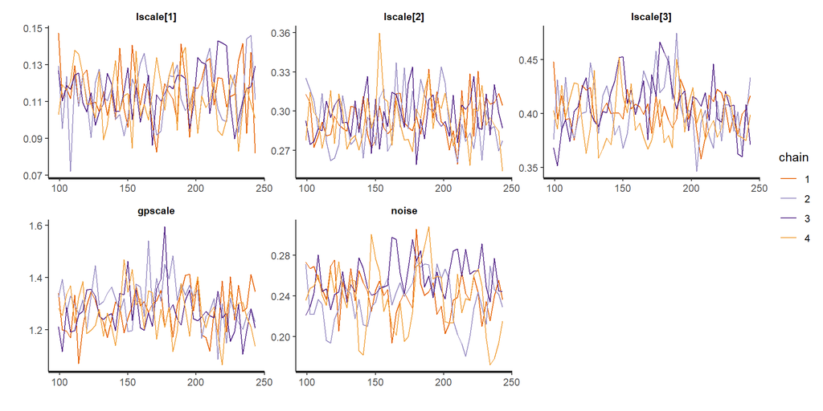

```r
traceplot(fit[[i]], pars = param, include = TRUE, unconstrain = FALSE, inc_warmup = FALSE, window = NULL, nrow = NULL, ncol = NULL)
```

### 6.2.5 Model evaluation

Root mean square error `rmse`, Bayesian $R^2$ (Coefficient of determination) `eR`, and expected log predictive density `elpd`.

```r
f_hsgp <- summary(fit[[i]], pars = c("f"), probs = c(0.025, 0.5, 0.975), digits_summary = 4)$summary[,c(1,4,6)]

# rmse against data
residual <- standata[[i]]$y_pred[vv_sample] - f_hsgp[,1]
rmse[i] <- round(sqrt(mean(residual^2)), 2)

# rmse against gp
residual_gp <- f_gp[vv_sample,1] - f_hsgp[,1]
rmse_gp[i] <- round(sqrt(mean(residual_gp^2)), 2)

# Coefficient of determination R^2
noise <- as.matrix(fit[[i]], pars = c("noise"))
sd_f <- apply(as.matrix(fit[[i]], pars = c("f")), 1, sd)
eR[i] <- round(median(sd_f^2/(sd_f^2 + noise^2)), 2)

# elpd
elpd[i] <- round(median(summary(fit[[i]], pars = c("elpd"))$summary[,1]), 2)
```

### 6.2.6 Diagnosis

Lengthscale estimate $\hat{\ell}_i$ in the HSGP approximation

```r
l_hat1[i] <- round(summary(fit[[i]], pars = "lscale[1]", probs = c(0.05, 0.95))$summary[,1], 2)
l_hat2[i] <- round(summary(fit[[i]], pars = "lscale[2]", probs = c(0.05, 0.95))$summary[,1], 2)
l_hat3[i] <- round(summary(fit[[i]], pars = "lscale[3]", probs = c(0.05, 0.95))$summary[,1], 2)
```

Check the diagnostic of whether $\, \hat{\ell}_i + 0.01 \geq \ell_i$ (5.1)

```r
check1[i] <- diagnostic(l1[i], l_hat1[i])
check2[i] <- diagnostic(l2[i], l_hat2[i])
check3[i] <- diagnostic(l3[i], l_hat3[i])
```

Summary diagnosis table

```r
diagnosis[[i]] <- data.frame(iter= c(i, i, i),
                              Dim= c("D1", "D2", "D3"),
                              l= c(l1[i], l2[i], l3[i]),
                              c= c(c1[i], c2[i], c3[i]),
                              m= c(m1[i], m2[i], m3[i]),
                              l_hat= c(l_hat1[i], l_hat2[i], l_hat3[i]),
                              'l_hat > l' = c(check1[i], check2[i], check3[i]),
                              rsme_gp = c(NA, rmse_gp[i], NA),
                              rsme = c(NA, rmse[i], NA),
                              R2 = c(NA, eR[i], NA),
                              elpd = c(NA, elpd[i], NA))
names(diagnosis[[i]]) <- c("iter", "Dim", "l", "c", "m", "l_hat", "l_hat + 0.01 > l", "rmse_gp", "rmse", "R^2", "elpd")

if(i==1){
  diagnosis[[i]]
}else{
  diagnosis[[i]] <- rbind(diagnosis[[i-1]],diagnosis[[i]])
  diagnosis[[i]]
}
```

| iter | Dim | l | c | m | l_hat | l_hat + 0.01 > l | rmse_gp | rmse | R^2 | elpd |
| --- | --- | --- | --- | --- | --- | --- | --- | --- | --- | --- |
| 1 | D1 | 0.50 | 1.6 | 6 | 0.14 | FALSE | NA | NA | NA | NA |
| 1 | D2 | 0.50 | 1.6 | 6 | 0.26 | FALSE | 0.58 | 0.63 | 0.60 | -0.89 |
| 1 | D3 | 1.00 | 3.2 | 6 | 0.24 | FALSE | NA | NA | NA | NA |
| 2 | D1 | 0.14 | 1.2 | 15 | 0.11 | FALSE | NA | NA | NA | NA |
| 2 | D2 | 0.26 | 1.2 | 9 | 0.29 | TRUE | 0.07 | 0.13 | 0.95 | 0.06 |
| 2 | D3 | 0.24 | 1.2 | 9 | 0.40 | TRUE | NA | NA | NA | NA |

## 6.3 Iteration 3

```r
i <- 3
print(paste("Iteration i =", i), quote = FALSE)
```

```
[1] Iteration i = 3
```

### 6.3.1 Setting $m$, $\ell$ and $c$

If the diagnostic $\hat{\ell}_{i-1} + 0.01 \geq \ell_{i-1}$ (5.1) is TRUE and iteration $i>2$ and diagnostic $\hat{\ell}_{i-2} + 0.01 \geq \ell_{i-2}$ (5.1) is FALSE:

1. Update $m_i = m_{i-1} + 2$
2. The boundary factor $c_i$ has to fulfill (4.2) where $c(\cdot)$ is evaluated as a function of $\hat{\ell}_{i-1}$
3. The lengthscale $\ell_i$ has to fulfill (4.1)

```r
if(diagnostic(l1[i-1], l_hat1[i-1]) & i>2 & !diagnostic(l1[i-2], l_hat1[i-2])){
  m1[i] <- m1[i-1] + 2
  c1[i] <- c_vs_l_QE(l=l_hat1[i-1], S=S1)
  l1[i] <- l_QE(c=c1[i], m=m1[i], S=S1)
}

if(diagnostic(l2[i-1], l_hat2[i-1]) & i>2 & !diagnostic(l2[i-2], l_hat2[i-2])){
  m2[i] <- m2[i-1] + 2
  c2[i] <- c_vs_l_QE(l=l_hat2[i-1], S=S2)
  l2[i] <- l_QE(c=c2[i], m=m2[i], S=S2)
}

if(diagnostic(l3[i-1], l_hat3[i-1]) & i>2 & !diagnostic(l3[i-2], l_hat3[i-2])){
  m3[i] <- m3[i-1] + 2
  c3[i] <- c_vs_l_QE(l=l_hat3[i-1], S=S3)
  l3[i] <- l_QE(c=c3[i], m=m3[i], S=S3)
}
```

If the diagnostic $\hat{\ell}_{i-1} + 0.01 \geq \ell_{i-1}$ (5.1) is TRUE and iteration $i>2$ and diagnostic $\hat{\ell}_{i-2} + 0.01 \geq \ell_{i-2}$ (5.1) is TRUE:

1. Update $m_i = m_{i-1}$
2. Update $c_i = c_{i-1}$
3. Update $\ell_i = \ell_{i-1}$

```r
if(diagnostic(l1[i-1], l_hat1[i-1]) & i>2 & diagnostic(l1[i-2], l_hat1[i-2])){
  m1[i] <- m1[i-1]
  c1[i] <- c1[i-1]
  l1[i] <- l1[i-1]
}

if(diagnostic(l2[i-1], l_hat2[i-1]) & i>2 & diagnostic(l2[i-2], l_hat2[i-2])){
  m2[i] <- m2[i-1]
  c2[i] <- c2[i-1]
  l2[i] <- l2[i-1]
}

if(diagnostic(l3[i-1], l_hat3[i-1]) & i>2 & diagnostic(l3[i-2], l_hat3[i-2])){
  m3[i] <- m3[i-1]
  c3[i] <- c3[i-1]
  l3[i] <- l3[i-1]
}
```

If the diagnostic $\hat{\ell}_{i-1} + 0.01 \geq \ell_{i-1}$ (5.1) is FALSE:

1. Update $\ell_i = \hat{\ell}_{i-1}$
2. The boundary factor $c_i$ has to fulfill (4.2)
3. The number of basis functions $m_i$ as a function of $\ell_i$ and $c_i$ by using (4.1)

```r
if(!diagnostic(l1[i-1], l_hat1[i-1])){
  l1[i] <- l_hat1[i-1]
  c1[i] <- c_vs_l_QE(l=l1[i], S=S1)
  m1[i] <- m_QE(c=c1[i], l=l1[i], S=S1)
}

if(!diagnostic(l2[i-1], l_hat2[i-1])){
  l2[i] <- l_hat2[i-1]
  c2[i] <- c_vs_l_QE(l=l2[i], S=S2)
  m2[i] <- m_QE(c=c2[i], l=l2[i], S=S2)
}

if(!diagnostic(l3[i-1], l_hat3[i-1])){
  l3[i] <- l_hat3[i-1]
  c3[i] <- c_vs_l_QE(l=l3[i], S=S3)
  m3[i] <- m_QE(c=c3[i], l=l3[i], S=S3)
}
```

### 6.3.2 Matrix of $D$-tuples

Matrix of $D$-tuples as in equation (10) in the [paper](https://arxiv.org/pdf/2004.11408.pdf)

```r
indices <- matrix(NA, m1[i]*m2[i]*m3[i], D)
mm=0;
for (r in 1:m1[i]){
    for (s in 1:m2[i]){
        for (t in 1:m3[i]){
            mm = mm+1
            indices[mm,] = c(r, s, t)
        }
    }
}
```

### 6.3.3 Data to be passed to Stan

```r
standata[[i]] <- list(D= D,
                      M= c(m1[i],m2[i],m3[i]),
                      M_nD= m1[i]*m2[i]*m3[i],
                      indices= indices,
                      L= c(c1[i], c2[i], c3[i]) * c(S1, S2, S3),
                      x_pred= x_pred,
                      y_pred= y_pred,
                      N_sample= N_sample,
                      N_pred= N_pred,
                      vv_sample= vv_sample
)
str(standata[[i]])
```

```
List of 10
 $ D        : num 3
 $ M        : num [1:3] 20 11 11
 $ M_nD     : num 2420
 $ indices  : int [1:2420, 1:3] 1 1 1 1 1 1 1 1 1 1 ...
 $ L        : num [1:3] 1.2 1.2 1.28
 $ x_pred   :'data.frame':  1331 obs. of  3 variables:
  ..$ x1: num [1:1331] -1 -0.8 -0.6 -0.4 -0.2 0 0.2 0.4 0.6 0.8 ...
  ..$ x2: num [1:1331] -1 -1 -1 -1 -1 -1 -1 -1 -1 -1 ...
  ..$ x3: num [1:1331] -1 -1 -1 -1 -1 -1 -1 -1 -1 -1 ...
  ..- attr(*, "out.attrs")=List of 2
  .. ..$ dim     : Named int [1:3] 11 11 11
  .. .. ..- attr(*, "names")= chr [1:3] "x1" "x2" "x3"
  .. ..$ dimnames:List of 3
  .. .. ..$ x1: chr [1:11] "x1=-1.0" "x1=-0.8" "x1=-0.6" "x1=-0.4" ...
  .. .. ..$ x2: chr [1:11] "x2=-1.0" "x2=-0.8" "x2=-0.6" "x2=-0.4" ...
  .. .. ..$ x3: chr [1:11] "x3=-1.0" "x3=-0.8" "x3=-0.6" "x3=-0.4" ...
 $ y_pred   : num [1:1331] 0.0105 0.3424 0.537 -0.4404 -1.4484 ...
 $ N_sample : int 300
 $ N_pred   : int 1331
 $ vv_sample: int [1:300] 798 1044 387 786 144 392 522 205 980 71 ...
```

### 6.3.4 Model fitting

Model fitting

```r
hsgp_mod <- cmdstanr::cmdstan_model(stan_file = "stancode_HSGP_3D.stan")
fit[[i]] <- hsgp_mod$sample(data= standata[[i]],
                                iter_warmup=100,
                                iter_sampling=150,
                                chains=4, thin=3, init=0.5,
                                adapt_delta=0.99,
                                save_warmup=TRUE)
fit[[i]] <- rstan::read_stan_csv(fit[[i]]$output_files())
```

Summaries and simulation chains of variable estimates

```r
param = c("lscale","gpscale","noise")
summary(fit[[i]], pars = param, probs = c(0.025, 0.5, 0.975))$summary
```

```
               mean     se_mean         sd       2.5%       50%     97.5%
lscale[1] 0.1181265 0.000892321 0.01299538 0.09282002 0.1175590 0.1419179
lscale[2] 0.2879417 0.001862883 0.01843046 0.25323288 0.2887105 0.3243263
lscale[3] 0.4329140 0.002351490 0.02524357 0.38771923 0.4316210 0.4822934
gpscale   1.2363001 0.008597442 0.09297170 1.09291500 1.2333750 1.4247778
noise     0.2222094 0.003848316 0.02842474 0.17658852 0.2212260 0.2813192
              n_eff      Rhat
lscale[1] 212.09770 0.9979911
lscale[2]  97.88155 1.0332892
lscale[3] 115.24322 1.0390616
gpscale   116.93997 1.0191001
noise      54.55716 1.1014187
```

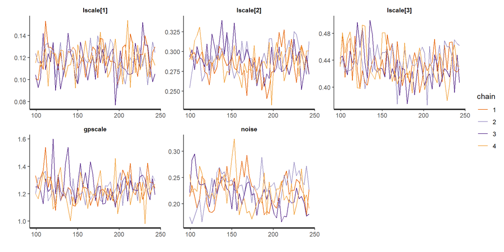

```r
traceplot(fit[[i]], pars = param, include = TRUE, unconstrain = FALSE, inc_warmup = FALSE, window = NULL, nrow = NULL, ncol = NULL)
```

### 6.3.5 Model evaluation

Root mean square error `rmse`, Bayesian $R^2$ (Coefficient of determination) `eR`, and expected log predictive density `elpd`.

```r
f_hsgp <- summary(fit[[i]], pars = c("f"), probs = c(0.025, 0.5, 0.975), digits_summary = 4)$summary[,c(1,4,6)]

# rmse against data
residual <- standata[[i]]$y_pred[vv_sample] - f_hsgp[,1]
rmse[i] <- round(sqrt(mean(residual^2)), 2)

# rmse against gp
residual_gp <- f_gp[vv_sample,1] - f_hsgp[,1]
rmse_gp[i] <- round(sqrt(mean(residual_gp^2)), 2)

# Coefficient of determination R^2
noise <- as.matrix(fit[[i]], pars = c("noise"))
sd_f <- apply(as.matrix(fit[[i]], pars = c("f")), 1, sd)
eR[i] <- round(median(sd_f^2/(sd_f^2 + noise^2)), 2)

# elpd
elpd[i] <- round(median(summary(fit[[i]], pars = c("elpd"))$summary[,1]), 2)
```

### 6.3.6 Diagnosis

Lengthscale estimate $\hat{\ell}_i$ in the HSGP approximation

```r
l_hat1[i] <- round(summary(fit[[i]], pars = "lscale[1]", probs = c(0.05, 0.95))$summary[,1], 2)
l_hat2[i] <- round(summary(fit[[i]], pars = "lscale[2]", probs = c(0.05, 0.95))$summary[,1], 2)
l_hat3[i] <- round(summary(fit[[i]], pars = "lscale[3]", probs = c(0.05, 0.95))$summary[,1], 2)
```

Check the diagnostic of whether $\, \hat{\ell}_i + 0.01 \geq \ell_i$ (5.1)

```r
check1[i] <- diagnostic(l1[i], l_hat1[i])
check2[i] <- diagnostic(l2[i], l_hat2[i])
check3[i] <- diagnostic(l3[i], l_hat3[i])
```

Summary diagnosis table

```r
diagnosis[[i]] <- data.frame(iter= c(i, i, i),
                              Dim= c("D1", "D2", "D3"),
                              l= c(l1[i], l2[i], l3[i]),
                              c= c(c1[i], c2[i], c3[i]),
                              m= c(m1[i], m2[i], m3[i]),
                              l_hat= c(l_hat1[i], l_hat2[i], l_hat3[i]),
                              'l_hat > l' = c(check1[i], check2[i], check3[i]),
                              rsme_gp = c(NA, rmse_gp[i], NA),
                              rsme = c(NA, rmse[i], NA),
                              R2 = c(NA, eR[i], NA),
                              elpd = c(NA, elpd[i], NA))
names(diagnosis[[i]]) <- c("iter", "Dim", "l", "c", "m", "l_hat", "l_hat + 0.01 > l", "rmse_gp", "rmse", "R^2", "elpd")

if(i==1){
  diagnosis[[i]]
}else{
  diagnosis[[i]] <- rbind(diagnosis[[i-1]],diagnosis[[i]])
  diagnosis[[i]]
}
```

| iter | Dim | l | c | m | l_hat | l_hat + 0.01 > l | rmse_gp | rmse | R^2 | elpd |
| --- | --- | --- | --- | --- | --- | --- | --- | --- | --- | --- |
| 1 | D1 | 0.500 | 1.60 | 6 | 0.14 | FALSE | NA | NA | NA | NA |
| 1 | D2 | 0.500 | 1.60 | 6 | 0.26 | FALSE | 0.58 | 0.63 | 0.60 | -0.89 |
| 1 | D3 | 1.000 | 3.20 | 6 | 0.24 | FALSE | NA | NA | NA | NA |
| 2 | D1 | 0.140 | 1.20 | 15 | 0.11 | FALSE | NA | NA | NA | NA |
| 2 | D2 | 0.260 | 1.20 | 9 | 0.29 | TRUE | 0.07 | 0.13 | 0.95 | 0.06 |
| 2 | D3 | 0.240 | 1.20 | 9 | 0.40 | TRUE | NA | NA | NA | NA |
| 3 | D1 | 0.110 | 1.20 | 20 | 0.12 | TRUE | NA | NA | NA | NA |
| 3 | D2 | 0.191 | 1.20 | 11 | 0.29 | TRUE | 0.05 | 0.11 | 0.96 | 0.15 |
| 3 | D3 | 0.204 | 1.28 | 11 | 0.43 | TRUE | NA | NA | NA | NA |

## 6.4 Iteration 4

```r
i <- 4
print(paste("Iteration i =", i), quote = FALSE)
```

```
[1] Iteration i = 4
```

### 6.4.1 Setting $m$, $\ell$ and $c$

If the diagnostic $\hat{\ell}_{i-1} + 0.01 \geq \ell_{i-1}$ (5.1) is TRUE and iteration $i>2$ and diagnostic $\hat{\ell}_{i-2} + 0.01 \geq \ell_{i-2}$ (5.1) is FALSE:

1. Update $m_i = m_{i-1} + 2$
2. The boundary factor $c_i$ has to fulfill (4.2) where $c(\cdot)$ is evaluated as a function of $\hat{\ell}_{i-1}$
3. The lengthscale $\ell_i$ has to fulfill (4.1)

```r
if(diagnostic(l1[i-1], l_hat1[i-1]) & i>2 & !diagnostic(l1[i-2], l_hat1[i-2])){
  m1[i] <- m1[i-1] + 2
  c1[i] <- c_vs_l_QE(l=l_hat1[i-1], S=S1)
  l1[i] <- l_QE(c=c1[i], m=m1[i], S=S1)
}

if(diagnostic(l2[i-1], l_hat2[i-1]) & i>2 & !diagnostic(l2[i-2], l_hat2[i-2])){
  m2[i] <- m2[i-1] + 2
  c2[i] <- c_vs_l_QE(l=l_hat2[i-1], S=S2)
  l2[i] <- l_QE(c=c2[i], m=m2[i], S=S2)
}

if(diagnostic(l3[i-1], l_hat3[i-1]) & i>2 & !diagnostic(l3[i-2], l_hat3[i-2])){
  m3[i] <- m3[i-1] + 2
  c3[i] <- c_vs_l_QE(l=l_hat3[i-1], S=S3)
  l3[i] <- l_QE(c=c3[i], m=m3[i], S=S3)
}
```

If the diagnostic $\hat{\ell}_{i-1} + 0.01 \geq \ell_{i-1}$ (5.1) is TRUE and iteration $i>2$ and diagnostic $\hat{\ell}_{i-2} + 0.01 \geq \ell_{i-2}$ (5.1) is TRUE:

1. Update $m_i = m_{i-1}$
2. Update $c_i = c_{i-1}$
3. Update $\ell_i = \ell_{i-1}$

```r
if(diagnostic(l1[i-1], l_hat1[i-1]) & i>2 & diagnostic(l1[i-2], l_hat1[i-2])){
  m1[i] <- m1[i-1]
  c1[i] <- c1[i-1]
  l1[i] <- l1[i-1]
}

if(diagnostic(l2[i-1], l_hat2[i-1]) & i>2 & diagnostic(l2[i-2], l_hat2[i-2])){
  m2[i] <- m2[i-1]
  c2[i] <- c2[i-1]
  l2[i] <- l2[i-1]
}

if(diagnostic(l3[i-1], l_hat3[i-1]) & i>2 & diagnostic(l3[i-2], l_hat3[i-2])){
  m3[i] <- m3[i-1]
  c3[i] <- c3[i-1]
  l3[i] <- l3[i-1]
}
```

If the diagnostic $\hat{\ell}_{i-1} + 0.01 \geq \ell_{i-1}$ (5.1) is FALSE:

1. Update $\ell_i = \hat{\ell}_{i-1}$
2. The boundary factor $c_i$ has to fulfill (4.2)
3. The number of basis functions $m_i$ as a function of $\ell_i$ and $c_i$ by using (4.1)

```r
if(!diagnostic(l1[i-1], l_hat1[i-1])){
  l1[i] <- l_hat1[i-1]
  c1[i] <- c_vs_l_QE(l=l1[i], S=S1)
  m1[i] <- m_QE(c=c1[i], l=l1[i], S=S1)
}

if(!diagnostic(l2[i-1], l_hat2[i-1])){
  l2[i] <- l_hat2[i-1]
  c2[i] <- c_vs_l_QE(l=l2[i], S=S2)
  m2[i] <- m_QE(c=c2[i], l=l2[i], S=S2)
}

if(!diagnostic(l3[i-1], l_hat3[i-1])){
  l3[i] <- l_hat3[i-1]
  c3[i] <- c_vs_l_QE(l=l3[i], S=S3)
  m3[i] <- m_QE(c=c3[i], l=l3[i], S=S3)
}
```

### 6.4.2 Matrix of $D$-tuples

Matrix of $D$-tuples as in equation (10) in the [paper](https://arxiv.org/pdf/2004.11408.pdf)

```r
indices <- matrix(NA, m1[i]*m2[i]*m3[i], D)
mm=0;
for (r in 1:m1[i]){
    for (s in 1:m2[i]){
        for (t in 1:m3[i]){
            mm = mm+1
            indices[mm,] = c(r, s, t)
        }
    }
}
```

### 6.4.3 Data to be passed to Stan

```r
standata[[i]] <- list(D= D,
                      M= c(m1[i],m2[i],m3[i]),
                      M_nD= m1[i]*m2[i]*m3[i],
                      indices= indices,
                      L= c(c1[i], c2[i], c3[i]) * c(S1, S2, S3),
                      x_pred= x_pred,
                      y_pred= y_pred,
                      N_sample= N_sample,
                      N_pred= N_pred,
                      vv_sample= vv_sample
)
str(standata[[i]])
```

```
List of 10
 $ D        : num 3
 $ M        : num [1:3] 22 11 11
 $ M_nD     : num 2662
 $ indices  : int [1:2662, 1:3] 1 1 1 1 1 1 1 1 1 1 ...
 $ L        : num [1:3] 1.2 1.2 1.28
 $ x_pred   :'data.frame':  1331 obs. of  3 variables:
  ..$ x1: num [1:1331] -1 -0.8 -0.6 -0.4 -0.2 0 0.2 0.4 0.6 0.8 ...
  ..$ x2: num [1:1331] -1 -1 -1 -1 -1 -1 -1 -1 -1 -1 ...
  ..$ x3: num [1:1331] -1 -1 -1 -1 -1 -1 -1 -1 -1 -1 ...
  ..- attr(*, "out.attrs")=List of 2
  .. ..$ dim     : Named int [1:3] 11 11 11
  .. .. ..- attr(*, "names")= chr [1:3] "x1" "x2" "x3"
  .. ..$ dimnames:List of 3
  .. .. ..$ x1: chr [1:11] "x1=-1.0" "x1=-0.8" "x1=-0.6" "x1=-0.4" ...
  .. .. ..$ x2: chr [1:11] "x2=-1.0" "x2=-0.8" "x2=-0.6" "x2=-0.4" ...
  .. .. ..$ x3: chr [1:11] "x3=-1.0" "x3=-0.8" "x3=-0.6" "x3=-0.4" ...
 $ y_pred   : num [1:1331] 0.0105 0.3424 0.537 -0.4404 -1.4484 ...
 $ N_sample : int 300
 $ N_pred   : int 1331
 $ vv_sample: int [1:300] 798 1044 387 786 144 392 522 205 980 71 ...
```

### 6.4.4 Model fitting

Model fitting

```r
hsgp_mod <- cmdstanr::cmdstan_model(stan_file = "stancode_HSGP_3D.stan")
fit[[i]] <- hsgp_mod$sample(data= standata[[i]],
                                iter_warmup=100,
                                iter_sampling=150,
                                chains=4, thin=3, init=0.5,
                                adapt_delta=0.99,
                                save_warmup=TRUE)
fit[[i]] <- rstan::read_stan_csv(fit[[i]]$output_files())
```

Summaries and simulation chains of variable estimates

```r
param = c("lscale","gpscale","noise")
summary(fit[[i]], pars = param, probs = c(0.025, 0.5, 0.975))$summary
```

```
               mean      se_mean         sd       2.5%       50%     97.5%
lscale[1] 0.1147357 0.0009612366 0.01355486 0.08599833 0.1156480 0.1376212
lscale[2] 0.2858314 0.0024794270 0.01839230 0.25216637 0.2846215 0.3265095
lscale[3] 0.4298567 0.0025964323 0.02518477 0.38118785 0.4287995 0.4809093
gpscale   1.2280267 0.0067636487 0.08970517 1.07964500 1.2248800 1.4187950
noise     0.2192583 0.0048364692 0.03014360 0.16650525 0.2176155 0.2777757
              n_eff      Rhat
lscale[1] 198.85176 0.9883073
lscale[2]  55.02620 1.0854689
lscale[3]  94.08531 1.0225604
gpscale   175.90286 0.9969178
noise      38.84484 1.1162950
```

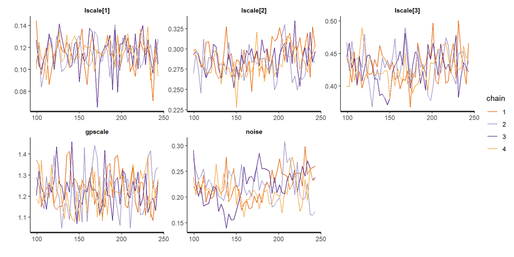

```r
traceplot(fit[[i]], pars = param, include = TRUE, unconstrain = FALSE, inc_warmup = FALSE, window = NULL, nrow = NULL, ncol = NULL)
```

### 6.4.5 Model evaluation

Root mean square error `rmse`, Bayesian $R^2$ (Coefficient of determination) `eR`, and expected log predictive density `elpd`.

```r
f_hsgp <- summary(fit[[i]], pars = c("f"), probs = c(0.025, 0.5, 0.975), digits_summary = 4)$summary[,c(1,4,6)]

# rmse against data
residual <- standata[[i]]$y_pred[vv_sample] - f_hsgp[,1]
rmse[i] <- round(sqrt(mean(residual^2)), 2)

# rmse against gp
residual_gp <- f_gp[vv_sample,1] - f_hsgp[,1]
rmse_gp[i] <- round(sqrt(mean(residual_gp^2)), 2)

# Coefficient of determination R^2
noise <- as.matrix(fit[[i]], pars = c("noise"))
sd_f <- apply(as.matrix(fit[[i]], pars = c("f")), 1, sd)
eR[i] <- round(median(sd_f^2/(sd_f^2 + noise^2)), 2)

# elpd
elpd[i] <- round(median(summary(fit[[i]], pars = c("elpd"))$summary[,1]), 2)
```

### 6.4.6 Diagnosis

Lengthscale estimate $\hat{\ell}_i$ in the HSGP approximation

```r
l_hat1[i] <- round(summary(fit[[i]], pars = "lscale[1]", probs = c(0.05, 0.95))$summary[,1], 2)
l_hat2[i] <- round(summary(fit[[i]], pars = "lscale[2]", probs = c(0.05, 0.95))$summary[,1], 2)
l_hat3[i] <- round(summary(fit[[i]], pars = "lscale[3]", probs = c(0.05, 0.95))$summary[,1], 2)
```

Check the diagnostic of whether $\, \hat{\ell}_i + 0.01 \geq \ell_i$ (5.1)

```r
check1[i] <- diagnostic(l1[i], l_hat1[i])
check2[i] <- diagnostic(l2[i], l_hat2[i])
check3[i] <- diagnostic(l3[i], l_hat3[i])
```

Summary diagnosis table

```r
diagnosis[[i]] <- data.frame(iter= c(i, i, i),
                              Dim= c("D1", "D2", "D3"),
                              l= c(l1[i], l2[i], l3[i]),
                              c= c(c1[i], c2[i], c3[i]),
                              m= c(m1[i], m2[i], m3[i]),
                              l_hat= c(l_hat1[i], l_hat2[i], l_hat3[i]),
                              'l_hat > l' = c(check1[i], check2[i], check3[i]),
                              rsme_gp = c(NA, rmse_gp[i], NA),
                              rsme = c(NA, rmse[i], NA),
                              R2 = c(NA, eR[i], NA),
                              elpd = c(NA, elpd[i], NA))
names(diagnosis[[i]]) <- c("iter", "Dim", "l", "c", "m", "l_hat", "l_hat + 0.01 > l", "rmse_gp", "rmse", "R^2", "elpd")

if(i==1){
  diagnosis[[i]]
}else{
  diagnosis[[i]] <- rbind(diagnosis[[i-1]],diagnosis[[i]])
  diagnosis[[i]]
}
```

| iter | Dim | l | c | m | l_hat | l_hat + 0.01 > l | rmse_gp | rmse | R^2 | elpd |
| --- | --- | --- | --- | --- | --- | --- | --- | --- | --- | --- |
| 1 | D1 | 0.500 | 1.60 | 6 | 0.14 | FALSE | NA | NA | NA | NA |
| 1 | D2 | 0.500 | 1.60 | 6 | 0.26 | FALSE | 0.58 | 0.63 | 0.60 | -0.89 |
| 1 | D3 | 1.000 | 3.20 | 6 | 0.24 | FALSE | NA | NA | NA | NA |
| 2 | D1 | 0.140 | 1.20 | 15 | 0.11 | FALSE | NA | NA | NA | NA |
| 2 | D2 | 0.260 | 1.20 | 9 | 0.29 | TRUE | 0.07 | 0.13 | 0.95 | 0.06 |
| 2 | D3 | 0.240 | 1.20 | 9 | 0.40 | TRUE | NA | NA | NA | NA |
| 3 | D1 | 0.110 | 1.20 | 20 | 0.12 | TRUE | NA | NA | NA | NA |
| 3 | D2 | 0.191 | 1.20 | 11 | 0.29 | TRUE | 0.05 | 0.11 | 0.96 | 0.15 |
| 3 | D3 | 0.204 | 1.28 | 11 | 0.43 | TRUE | NA | NA | NA | NA |
| 4 | D1 | 0.095 | 1.20 | 22 | 0.11 | TRUE | NA | NA | NA | NA |
| 4 | D2 | 0.191 | 1.20 | 11 | 0.29 | TRUE | 0.05 | 0.11 | 0.96 | 0.16 |
| 4 | D3 | 0.204 | 1.28 | 11 | 0.43 | TRUE | NA | NA | NA | NA |